# Sensory and Motor Variance in Adaptation and Proprioceptive Recalibration

Marius ’t Hart

20/11/2022

Variance in movements has sometimes been seen as a measure of exploration, which is thought to support motor adaptation. For example, people with larger movement variability may adapt to a perturbation quicker. The idea is that people who explore more, find the correct solution faster (goole terms: “exploration - exploitation”).

Similarly, if localization of an unseen hand after an outward reach depends on proprioception, and this sensory signal may be recalibrated, then a maximum likelihood approach would predict that people with less reliable (i.e. more variable) proprioception, recalibrated proprioception to a larger degree.

We have published four papers on related topics, that all use the same paradigm. Here we combine all this data to have a suitable data set to probe questions related to the role that variance has in adaptation processes. For some questions, we can include pilot data where no adaptation was recorded (i.e. only aligned sessions are available).

We start by installing a package with generic functions for analyzing reach data.

```r
if (!require(Reach)) {
  if (!require(remotes)) {
    install.packages(remotes)
  }
  remotes::install_github('thartbm/Reach', ref='main', force=TRUE)
}
library(Reach)
```

Now we load all the functions used specifically for this project. They are separated in source files, grouped by topic:

```r
# here are some general utility functions:
source('R/util.R')
# this does data pre-processing:
source('R/data.R')
# make plots/figures:
source('R/figures.R')
# do statistics:
source('R/stats.R')
```

[output not shown]

[output not shown]

[output not shown]

```r
# extra crappy things:
source('R/try_out.R')
```

Now we are ready to download the full data set:

```r
# from the data set, we are interested in groups that all learned the
# same 30 degree rotation, without instructions


# 'control', 'instructed', 'control60', 'instructed60',
# 'cursorjump', 'handview', 'older_control', 'older_instructed'
# 'EDS', 'EDSmatch', 'org_control', 'org_instructed', 'org_control60', and
# 'org_instructed60'

groups<- c('control',
           'instructed',
           'control60',
           'instructed60',
           'cursorjump',
           'handview',
           'older_control',
           'older_instructed',
           'EDS',
           'EDSmatch'
)

# downloadData(folder='data',
#              unzip=TRUE,
#              removezips=TRUE,
#              checkfiles=TRUE,
#              groups=groups,
#              sections=c('aligned','rotated'),
#              overwrite=TRUE)


groups <- c(
           'org_control',
           'org_instructed',
           'org_control60',
           'org_instructed60'
           )

# downloadData(folder='data',
#              unzip=TRUE,
#              removezips=TRUE,
#              checkfiles=TRUE,
#              groups=groups,
#              sections=c('aligned','rotated'),
#              overwrite=TRUE)
```

And we can test if all of the data is there:

```r
groups <- c('control',
            'instructed',
            'control60',
            'instructed60',
            'cursorjump',
            'handview',
            'older_control',
            'older_instructed',
            'EDS',
            'EDSmatch'
            )

sessions <- c('aligned',
              'rotated')

tasks <- c('training',
           'activelocalization',
           'passivelocalization',
           'nocursor')

# dataChecks( groups   = groups,
#             sessions = sessions,
#             tasks    = tasks )

groups <- c('org_control',
            'org_instructed',
            'org_control60',
            'org_instructed60')
sessions <- c('aligned')

# dataChecks( groups   = groups,
#             sessions = sessions,
#             tasks    = tasks )
```

As a final preparation we get a file with descriptors for several measurements for every participant. This also takes some time, but has to be done only once.

```r
# getAllDescriptors()
```

# Before adaptation

What is the variance in all these measures? We look at variance in training trials, no-cursor trials, and in active and passive localization. And these 4, we split by age as well.

Let’s first see the data:

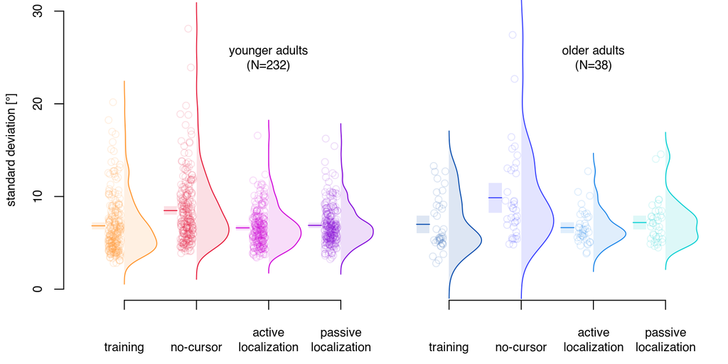

```r
fig4_sd_distributions()
```

The variance (or standard deviation, really) is higher in no-cursor trials it seems. At first sight, there doesn’t appear to be any other effect. Let’s test this with a Bayesian ANOVA.

```r
baselineVarianceTests()
```

```
## Inclusion Bayes Factors (Model Averaged)
##
##              P(prior) P(posterior) Inclusion BF
## variable         0.60         1.00     6.86e+15
## age              0.60         0.39        0.425
## age:variable     0.20         0.03        0.124
##
## * Compared among: all models
## *    Priors odds: uniform-equal
```

In the figure it was clear that no-cursors had higher variance than the other types of trials. Let’s see which variables have different variance from each other.

```r
baselineVarianceFollowUps()
```

```
## = = = = = = = = =
## compare ALIGNED_NOCURSOR_SD with ALIGNED_TRAINING_SD:
## BF: 2488283019978.1533
##
## = = = = = = = = =
## compare ALIGNED_NOCURSOR_SD with ALIGNED_ACTIVELOCALIZATION_SD:
## BF: 18708018669666.4688
##
## = = = = = = = = =
## compare ALIGNED_NOCURSOR_SD with ALIGNED_PASSIVELOCALIZATION_SD:
## BF: 902549362.7750
##
## = = = = = = = = =
## compare ALIGNED_TRAINING_SD with ALIGNED_ACTIVELOCALIZATION_SD:
## BF: 0.1543
##
## = = = = = = = = =
## compare ALIGNED_TRAINING_SD with ALIGNED_PASSIVELOCALIZATION_SD:
## BF: 0.0719
##
## = = = = = = = = =
## compare ALIGNED_ACTIVELOCALIZATION_SD with ALIGNED_PASSIVELOCALIZATION_SD:
## BF: 197.1613
```

Indeed there is very good evidence that no-cursor trials have higher variance than the other 3 types of reaches. There is also evidence that the variance in reach training trials is equal to that in the two types of localization trials.

Finally, there is evidence that there is a difference in the amount of variance in the two types of localization trials. Given the large number of participants, however, that last effect might not be as big or meaningful as expected. We’ll look into this some more next.

*If* active hand localization can use both afferent and efferent signals to determine where the hand is, whereas passive hand localization can only use afferent signals, *and if* efferent and afferent signals are combined in a Bayes optimal way (e.g. as a Maximum Likelihood Estimate or MLE) *then* the variance in passive localization should be larger than in active localization. Let’s plot this. Since there was no effect of age, we pool all participants.

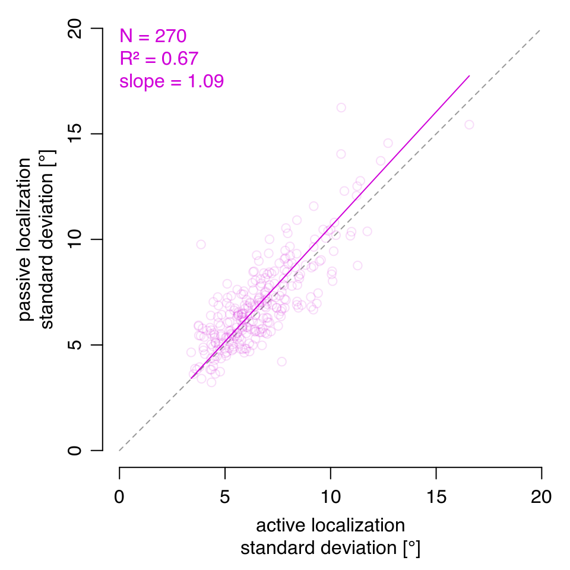

```r
fig6_efferent_localization()
```

Data points above the identity line are participants where the variance (sd) in passive localization is larger than in active localization, and those would be in line with an MLE or Bayes optimal integration account of afferent and efferent signals in these tasks. While there are a lot of data points that are in line with an MLE-like account (159/270 = 58.8%), there are also a lot of participants with data points that go against an MLE account (111/270 = 41.1%). On average the standard deviation in passive localization is 0.3 degrees larger than that in active localization, and this difference is significant (t(269)=4.07, p<.001, $BF_{10}$= 197.1). However, if we’d want to do “reverse MLE”, in order to get an estimate of the contribution of efferent signals, this would require all data to have the property that variance is higher in passive as compared to active localization, which is not the case. This argues against a straightforward Bayes-optimal integration of efferent and afferent signals in hand localization as measured here.

Rather than throw out nearly half of participants where this does not work, we can try a “reverse MLE” on the group averages, to get an idea of how much efferent signals contribute to hand localization in our population overall. We’ll calculate the weights only, for now, based on the aligned session. The biases are roughly zero there, so that estimating the size of an aligned signal based on two aligned measurements will be dominated by noise. However, we could try later on to do the same with rotated data, where the estimates are not around zero.

First, the variance of the combined signals (in active localization), would be related to the variance from proprioception alone (or passive localization) and that of the efferent signals (not measures). Taken from Ernst & Banks (2002):

$\sigma^2_{ae} = \frac{\sigma^2_a\cdot\sigma^2_e}{\sigma^2_a + \sigma^2_e}$

Where we measured $\sigma^2_{ae}$ and $\sigma^2_a$ in active and passive localization respectively.

And the mean of the combined signal is the weighted sum of the means of the contributing signals, where the weights are:

$w_i\frac{1/\sigma^2_i}{\sum_{j=1}^{n}1/\sigma^2_j}$

We’d need to know the variance of the contribution of the efferent signal to overall hand localization, which would be:

$\sigma^2_{e}=-\sigma^2_{ae}\cdot\frac{\sigma^2_{a}}{\sigma^2_{ae}-\sigma^2_a}$

As an approximation, we use the squared average standard deviation as the variance, and use that to estimate the relative weights of efferent and afferent signals in hand localization:

```r
knitr::kable(MLE_weights())
```

| variable | value |
| --- | --- |
| sig2_ae | 43.8191751 |
| sig2_a | 47.9619623 |
| sig2_e | 507.3042658 |
| w_a | 0.9136235 |
| w_e | 0.0863765 |

That is, 91.36% afferent versus 8.64% efferent in the combined signal. If MLE is indeed the mechanism. We’ll revisit this later in the section on data from the rotated session.

Regardless, the purple line in the plot is an orthogonal distance regression (or PCA-based regression) that does not assume any directionality of the relationship (as opposed to a regular regression). With a slope close to 1, and a fairly high $R^2$, the relationship between the two types of localization is fairly high, showing that either one could predict the other and probably that the participants are relatively reliable in how they perform the experiments.

One thing to keep in mind is that the active localization is performed after the movement has been completed, and the efferent signal might have a bigger influence during the movement than after. So while this data shows no evidence of integration of efferent and afferent signals (Bayes / MLE style) that could be because it is particularly hard to measure the effect of efferent signals on hand localization.

That said, we’re also interested in if and how the variance in the other variables relate to each other.

First, we look at reaches with and without feedback:

1. reach training variability
2. open-loop reach variability
3. relation

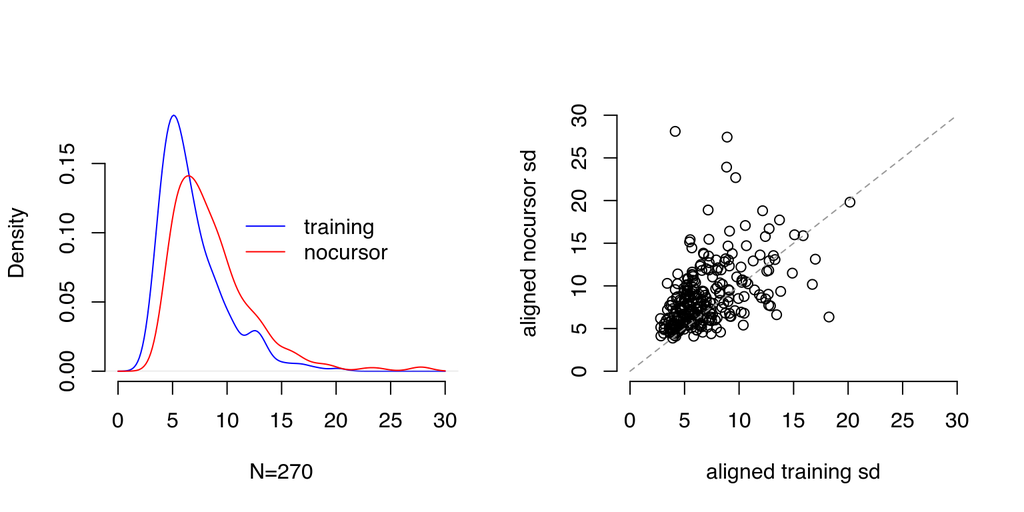

```r
plotBaselineVariability(groups='all',
                        x='training',
                        y='nocursor')
```

Then, we look at active and passive hand localization:

4. active hand localization variability
5. passive hand localization variability
6. relation

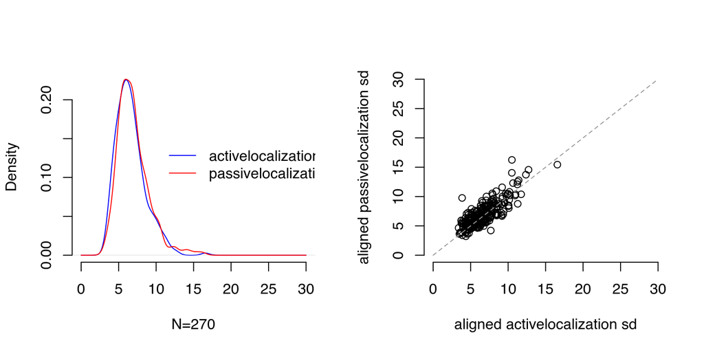

```r
plotBaselineVariability(groups='all',
                        x='activelocalization',
                        y='passivelocalization')
```

# After adaptation

## Predicting localization shifts

If the sensory modality with the larger uncertainty is the one that gets recalibrated the most, then does it also make sense that people with larger localization variance recalibrate proprioception more?

If so, we ask: does higher variance in hand localization relate to larger or smaller shifts in hand localization after training?

Is this different for active or passive localization? Or should we be looking at the difference?

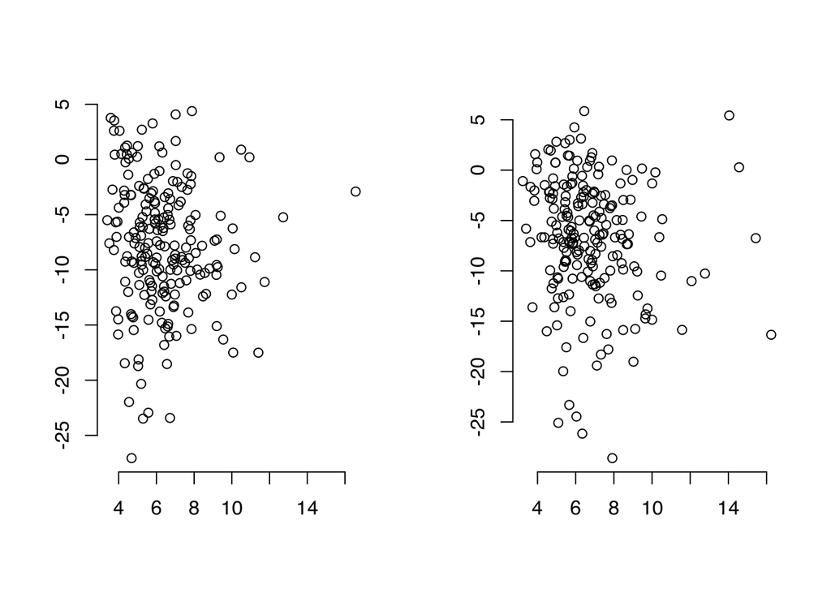

```r
plotPredictedAdaptation(IVs=c('activelocalization_sd',   'passivelocalization_sd'),
                        DVs=c('activelocalization_shift','passivelocalization_shift'),
                        groups=c("handview", "instructed60", "older_instructed", "control60", "EDSmatch", "instructed", "cursorjump", "EDS", "control", "older_control") )
```

## Predicting adaptation rate

Here we explore the exploration-exploitation hypothesis: people with more reach variance learn/adapt faster because they can exploit what they learn during this exploration.

Is the speed of adaptation related to any of the baseline reach variance measures?

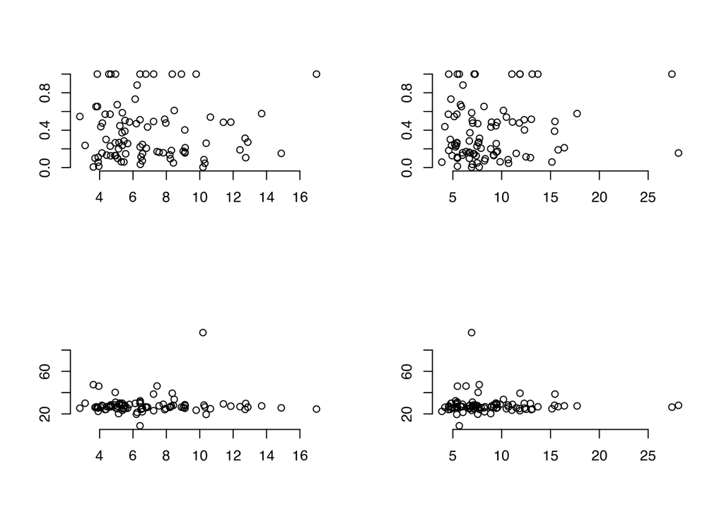

```r
plotPredictedAdaptation(IVs=c('training_sd',  'nocursor_sd',   'training_sd',        'nocursor_sd'),
                        DVs=c('training_rate','training_rate', 'training_asymptote', 'training_asymptote'),
                        groups=c('control','EDS','EDSmatch','older_control','cursorjump'))
```

## Predicting adaptation asymptote

Maybe it’s not the rate of change that is predicted, but the asymptote: how much you learn or adapt?

Is the amount of adaptation related to any of the baseline variance measures?

(Plotted above: bottom row.)

## Predicting reach aftereffects

Are with/without strategy reach aftereffects related to any of the baseline variance measures? (In particular variance in baseline no-cursor reach deviations.)

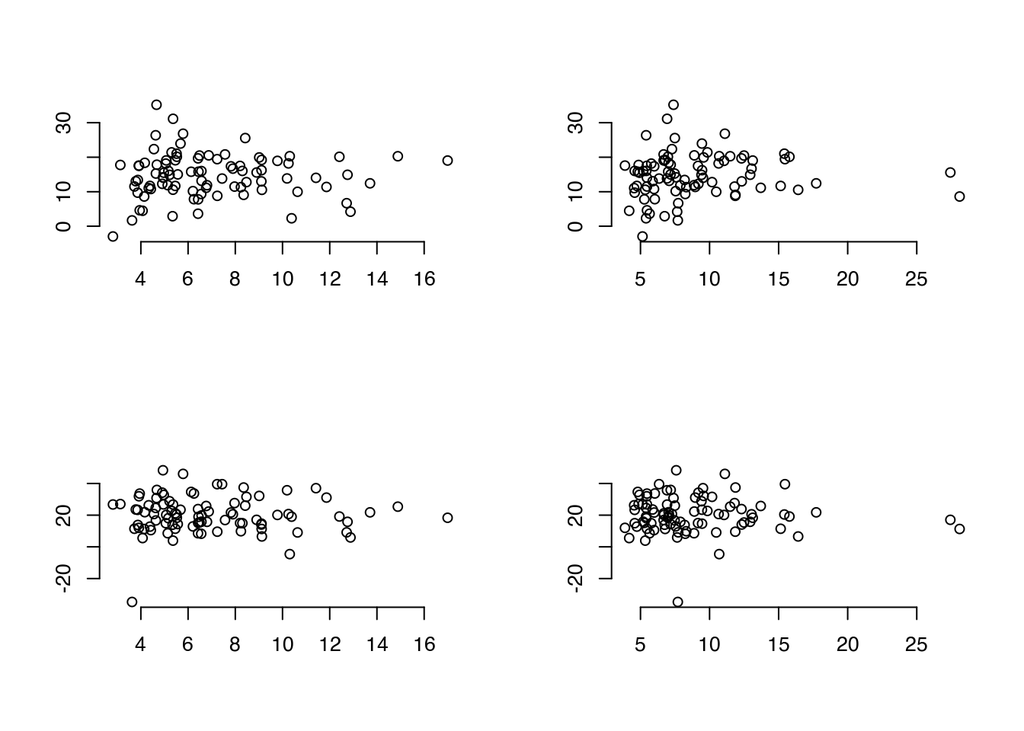

```r
plotPredictedAdaptation(IVs=c('training_sd', 'nocursor_sd', 'training_sd', 'nocursor_sd'),
                        DVs=c('exclusion',   'exclusion',   'inclusion',   'inclusion'),
                        groups=c('control','EDS','EDSmatch','older_control','cursorjump'))
```

# Demographics

Here we could look at effects of age, sex and other demographics.

## Variability in Localization and Sex

This is the effect of sex on aligned localization variability. We only look at people who self-identified their biological sex as male or female:

```
## Bayes factor analysis
## --------------
## [1] Alt., r=0.707 : 0.3011273 ±0.05%
##
## Against denominator:
##   Null, mu1-mu2 = 0
## ---
## Bayes factor type: BFindepSample, JZS
##
## Bayes factor analysis
## --------------
## [1] Alt., r=0.707 : 0.1828779 ±0.07%
##
## Against denominator:
##   Null, mu1-mu2 = 0
## ---
## Bayes factor type: BFindepSample, JZS
```

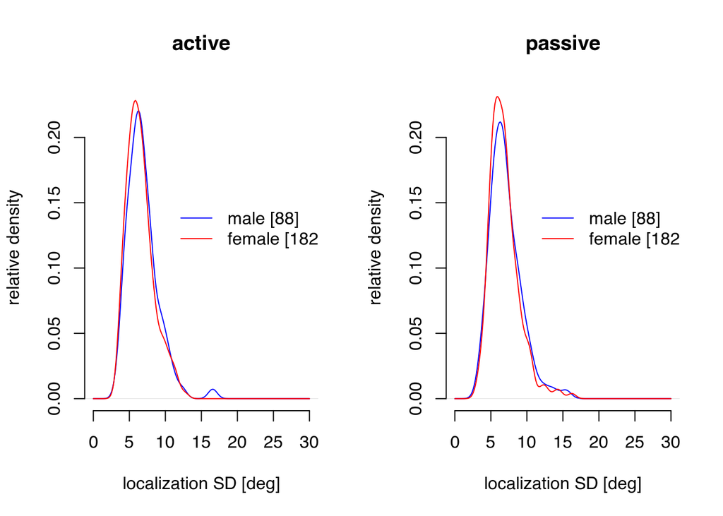

```r
plotBaselineVariabilitySex()
```

There is some evidence that biases in reaching depend on sex, so we might also want to test that.

# Try out plots

Here are some things I was apparently trying out.

## Decay of Localization Bias

Decay of localization biases across the 18 trials of each rotated block. There might be a break point between trials 9 and 10, as each participant only does the first or second half as active or passive localization.

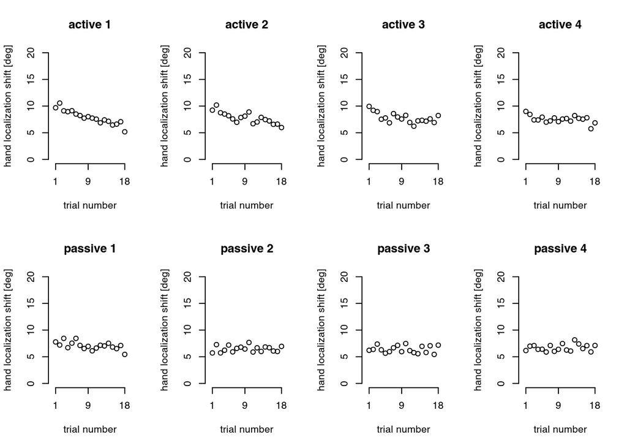

```r
plotLocalizationDecay()
```

To check: only for active localization, early on in the rotated session is there some form of decay. Later on it stabilizes. Does it stabilize at the same point as where passive localization is?

## Decay of Reach Aftereffects

Decay of reach aftereffects across the 18 trials of each rotated no-cursor block. These are only groups/conditions with normal feedback, a 30 degree rotation and without instructions about the rotation (4 groups: ‘control’, ‘older_control’, ‘EDS’ and ‘EDSmatch’). This figure/data set is split by Exclude first and Include first, but each row of panels in the figures is based on the same subset of participants, and each participant only contributes to 1 row of panels.

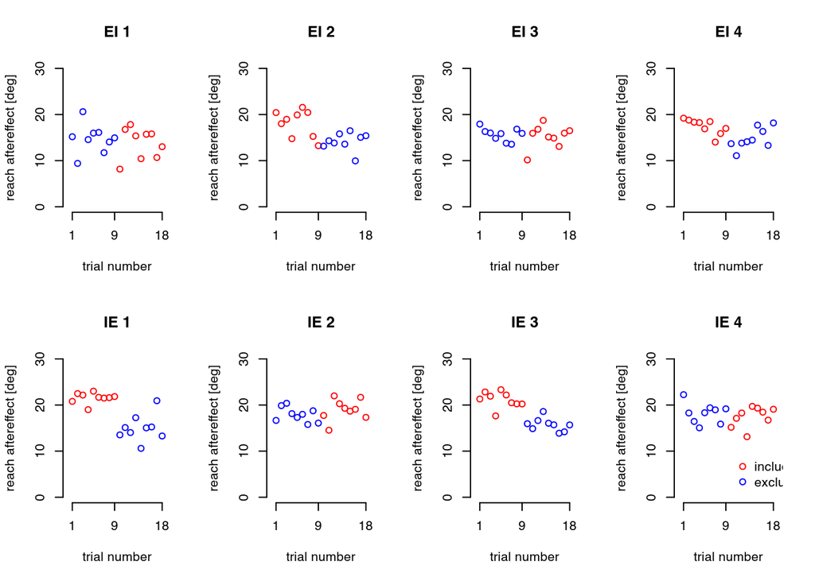

```r
plotRAEdecay()
```

There might be some subtle differences, e.g., include strategy reach aftereffects are higher than exclude strategy reach aftereffects in blocks where you start with include strategy no-cursor trials.

# No-cursors predicted by variance in proprioception

Is variance in no-cursor reaches predicted by localization?

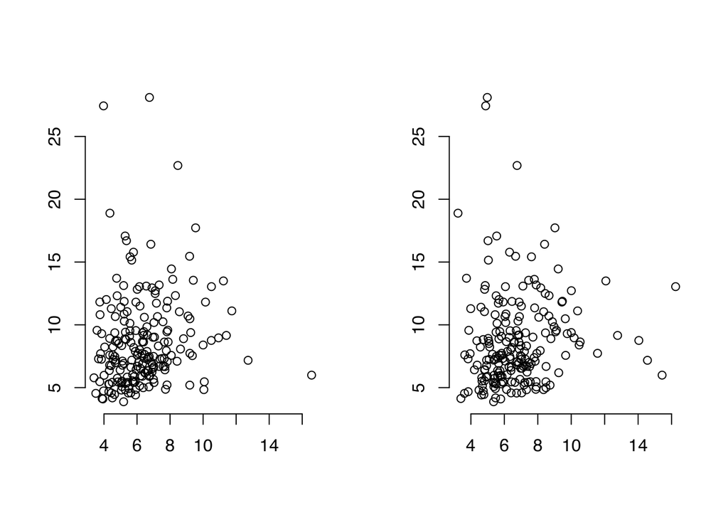

```r
plotPredictedAdaptation(IVs=c('activelocalization_sd', 'passivelocalization_sd'),
                        DVs=c('aligned_nocursor_sd',   'aligned_nocursor_sd'),
                        groups=c("handview", "instructed60", "older_instructed", "control60", "EDSmatch", "instructed", "cursorjump", "EDS", "control", "older_control") )
```